# TO404-HW4

Dawson Wang

December 2, 2020

# 1 Initialize

## 1.1 Packages Used

```r
library(lubridate)
library(gender)
library(dplyr)
```

```r
library(ggplot2)
library(leaflet)
```

## 1.2 Read and Clean Data

```r
abnyc <- read.csv("AB_NYC_2019.csv", stringsAsFactors = TRUE)
abnyc$id <- as.factor(abnyc$id)
abnyc$name <- as.character(abnyc$name)
abnyc$host_name <- as.character(abnyc$host_name)
abnyc$host_id <- as.factor(abnyc$host_id)
abnyc$last_review <- ymd(abnyc$last_review)
gen <- as.vector(gender(abnyc$host_name))
gen$proportion_male <- gen$proportion_female <- gen$year_min <- gen$year_max <- NULL
gen <- unique(gen)
names(gen)[names(gen) == "name"] <- "host_name"
data <- merge(x = abnyc, y = gen, by.x = "host_name", by.y = "host_name", all.x = TRUE)
data$gender <- as.factor(data$gender)
data$gender <- as.factor(ifelse(is.na(data$gender), "unknown", ifelse(data$gender == "male", "male", "female")))
data$nameLength <- nchar(data$name)
data$keywords <- as.factor(ifelse(grepl("Luxur", data$name), "Luxury", ifelse(grepl("eclectic", data$name), "Eclectic", ifelse(grepl("rare", data$name), "Rare", ifelse(grepl("renovated", data$name), "Renovated", ifelse(grepl("peaceful", data$name), "Peaceful", ifelse(grepl("contemporary", data$name), "Contemporary", ifelse(grepl("resort", data$name), "Resort", NA))))))))
```

# 2 Calculating Metrics

## 2.1 Average Rental Rate by Host’s Gender

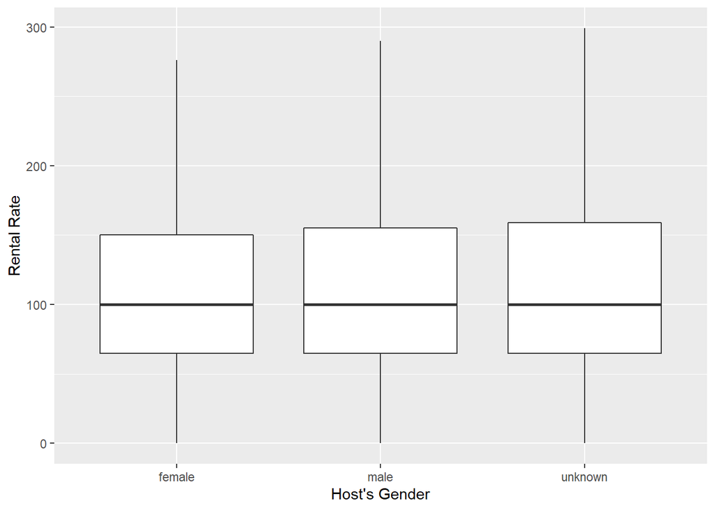

```r
data[data$price < 300,] %>%
  group_by(gender) %>%
  ggplot(aes(x = gender, y = price)) + geom_boxplot(outlier.shape = NA) + labs(x = "Host's Gender", y = "Rental Rate")
```

```r
tapply(data$price, data$gender, mean)
```

```
##   female     male  unknown
## 148.5858 154.2744 159.6193
```

There does not seem to be a significant difference between rental prices offered by male or female hosts.

## 2.2 Rental Rates by Neighborhood

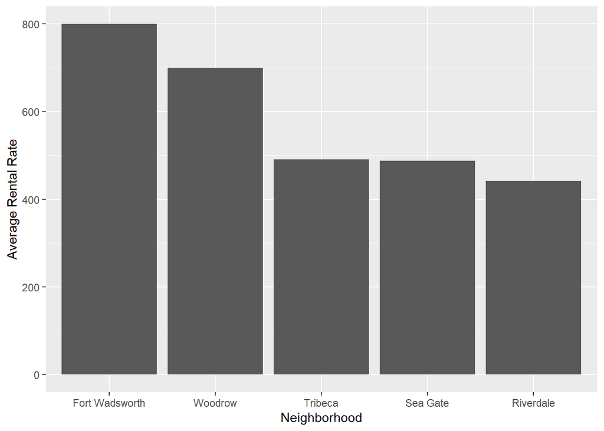

```r
data %>%
  group_by(neighbourhood) %>%
  summarise(
    avgPrice = mean(price, na.rm = TRUE)
  ) %>%
  arrange(desc(avgPrice)) %>%
  slice(1:5) %>%
  ggplot(aes(x = reorder(neighbourhood, -avgPrice), y = avgPrice)) + geom_col() + labs(x = "Neighborhood", y = "Average Rental Rate")
```

Fort Wadsworth and Woodrow are in Staten Island; Tribeca is in Manhattan; Sea Gate is in Brooklyn; Riverdale is in Bronx. Interestingly enough, the top two most expensive neighborhoods lie in the moderately-priced neighborhood group of Staten Island (according to chart below)

## 2.3 Rental Rates by Neighborhood Group

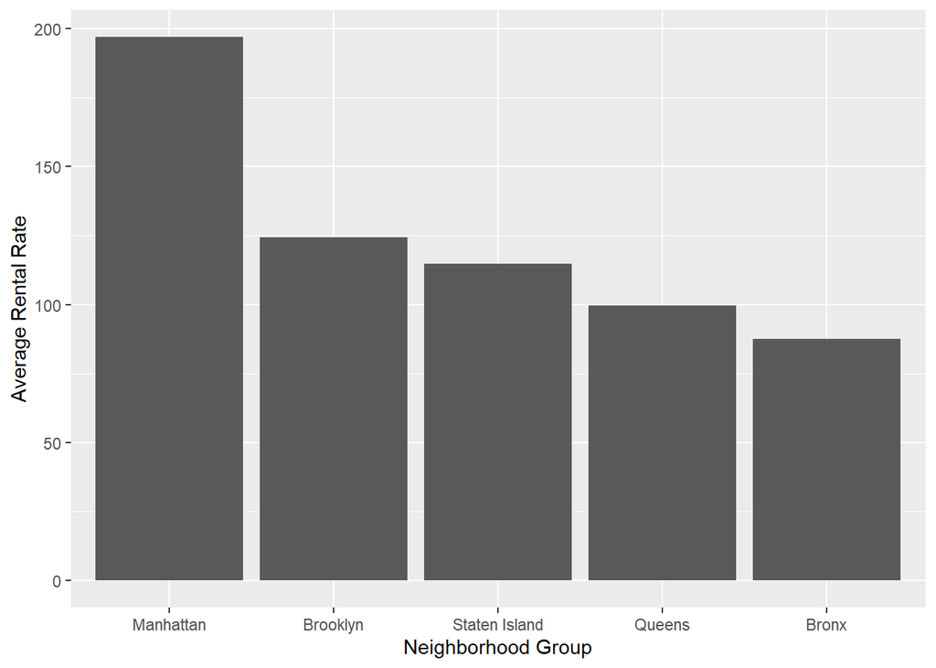

```r
group_by(data, neighbourhood_group) %>%
  summarise(
    avgPrice = mean(price, na.rm = TRUE)
  ) %>%
  ggplot(aes(x = reorder(neighbourhood_group, -avgPrice), y = avgPrice)) + geom_col() + labs(x = "Neighborhood Group", y = "Average Rental Rate")
```

Manhattan has the most expensive AirBnB rental rates, as expected.

## 2.4 Effects of Reviews

### 2.4.1 Reviews per Month

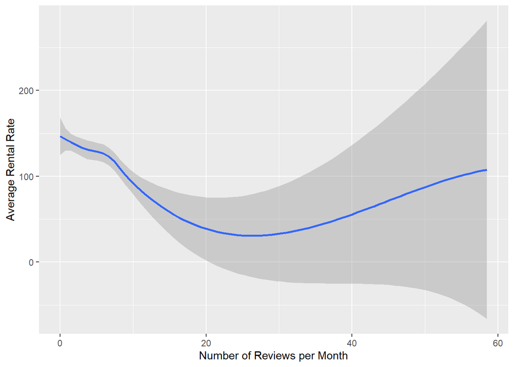

```r
data %>%
  group_by(reviews_per_month) %>%
  summarise(
    avgPrice = mean(price, na.rm = TRUE)
  ) %>%
    ggplot(aes(x = reviews_per_month, y = avgPrice)) + geom_smooth() + labs(x = "Number of Reviews per Month", y = "Average Rental Rate")
```

Due to the wide variation in rental rates as reviews per month increases, this graph may not be very meaningful. However, it’s still interesting to see a clear inflection point at all. Customer expectations for housing quality in different neighborhoods/neighborhood groups could be a confounding variable, since tenants presumably post reviews only when their experience deviates from their expectations; this could be causing the pattern we see.

### 2.4.2 Average Number of Reviews

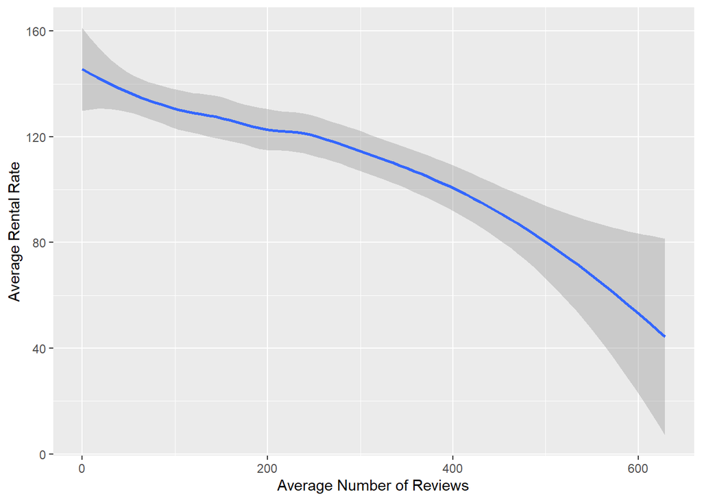

```r
data %>%
  group_by(number_of_reviews) %>%
  summarise(
    avgPrice = mean(price, na.rm = TRUE)
  )%>%
  ggplot(aes(x = number_of_reviews, y = avgPrice)) + geom_smooth() + labs(x = "Average Number of Reviews", y = "Average Rental Rate")
```

Average rental rate decreases as the number of reviews increases. This trend is expected since cheaper listings are accessible to more people, leading to more reviews being written.

## 2.5 Effects of Listing Descriptions

### 2.5.1 Length of Listing Name

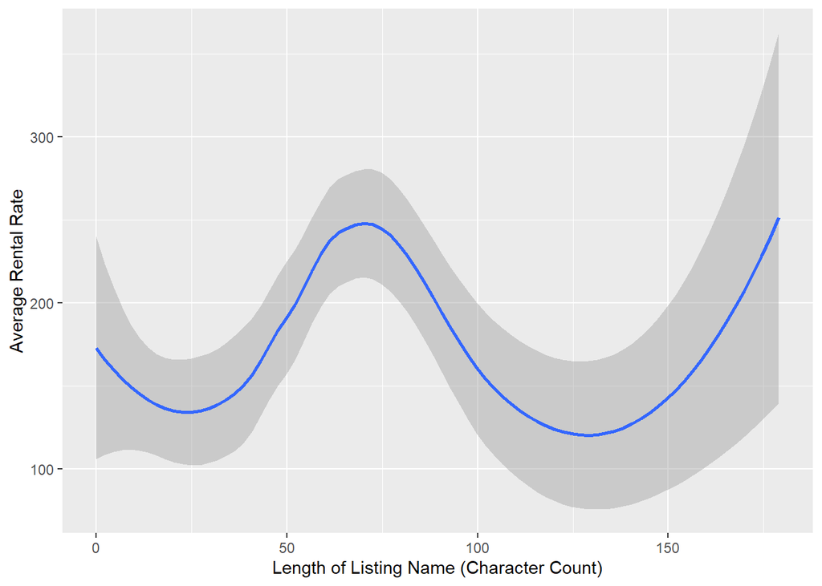

```r
data %>%
  group_by(nameLength) %>%
  summarise(
    avgPrice = mean(price, na.rm = TRUE),
  ) %>%
  ggplot(aes(x = nameLength, y = avgPrice)) + geom_smooth() + labs(x = "Length of Listing Name (Character Count)", y = "Average Rental Rate")
```

As character count increases, rental price looks to hit a local maximum at around 65-70 characters. This could be due to customers having an easier time browsing shorter names (65-70 characters long), causing slightly higher demand due to higher probability of getting shortlisted by the customer, justifying higher rates offered by the host. As names get longer than ~125 characters, however, rates also begin to increase once again - potentially due to higher click rates from attention-catching name lengths leading to the same aforementioned outcome.

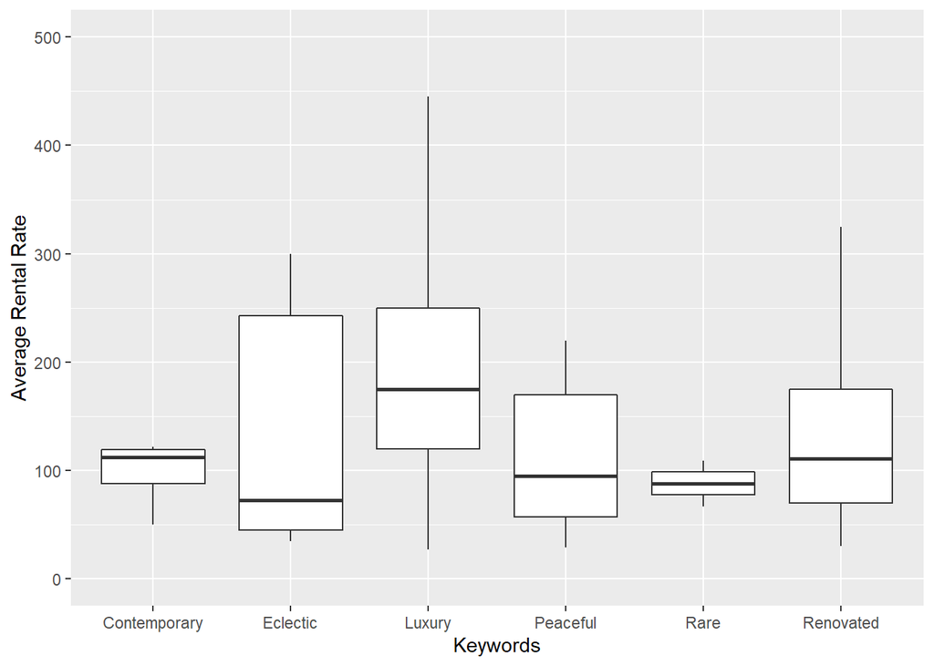

```r
na.omit(data) %>%
  group_by(keywords) %>%
  summarise(
    avgPrice = price
  ) %>%
  ggplot(aes(x = keywords, y = avgPrice)) + geom_boxplot(outlier.shape = NA) + labs(x = "Keywords", y = "Average Rental Rate") + ylim(0,500)
```

Listing names that include luxury/luxurious have higher rental rates than listings with other keywords in this analysis.

## 2.6 Other Metrics

### 2.6.1 Minimum Number of Nights to Neighborhood Groups

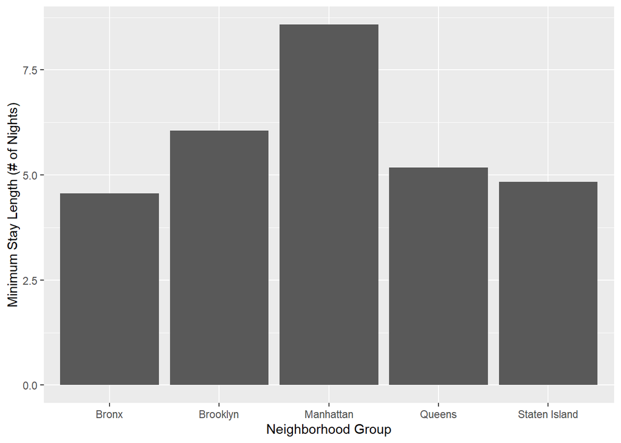

```r
group_by(data, neighbourhood_group) %>%
  summarise(
    minNights = mean(minimum_nights, na.rm = TRUE)
  ) %>%
  ggplot(aes(x = neighbourhood_group, y = minNights)) + geom_col() + labs(x = "Neighborhood Group", y = "Minimum Stay Length (# of Nights)")
```

### 2.6.2 Number of Reviews by Neighborhood Group

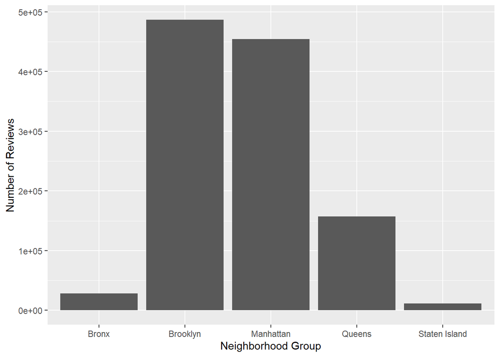

```r
ggplot(data, aes(x = neighbourhood_group , y = number_of_reviews)) + geom_col() + labs(x = "Neighborhood Group", y = "Number of Reviews")
```

# 3 Map of Manhattan

## 3.1 Top 100 Rentals by Price

```r
data100 <- head(data[order(data$price, decreasing = TRUE), ], 100)
leaflet(data100) %>%
  addTiles() %>%
  addMarkers( popup = paste("ID:", data100$id, "<br>", "Price: $", data100$price)) %>%
  setView(-73.96,40.75, zoom = 9)
```

```
## Assuming "longitude" and "latitude" are longitude and latitude, respectively
```

[interactive chart not shown]

A large majority of the 100 most expensive rentals are in Manhattan, with many also located in central Brooklyn.